Software Product Mastering / Das unsichtbare Biest / Das "Was" und das "Wie" / Stacey Matrix / Cynefin-Modell / Softwarekomplexität seit 1980 / Conways law / Zusammenfassung Theorie

# Management Stile

[output not shown]

1. **Autoritärer Stil**:
   - Vorteile: Schnelle Entscheidungen, hilfreich bei unerfahrenen Teams
   - Nachteile: Wenig Kreativität und Motivation, hinderlich für Innovation
   - Eignung: Selten geeignet, da Softwareentwicklung Flexibilität erfordert
2. **Demokratischer Stil**:
   - Vorteile: Fördert Kreativität und Eigenverantwortung, ideal für agile Methoden
   - Nachteile: Langsame Entscheidungen, ungeeignet für schnelle Entscheidungsanforderungen
   - Eignung: Sehr geeignet für kollaborative und agile Umgebungen
3. **Laissez-faire Stil**:
   - Vorteile: Hohe Autonomie, fördert kreative Ansätze
   - Nachteile: Erfordert hohe Eigenverantwortung, kann chaotisch werden
   - Eignung: Geeignet für selbstorganisierte, erfahrene Teams
4. **Transformationaler Stil**:
   - Vorteile: Motivation durch Vision, fördert kontinuierliches Lernen und Innovation
   - Nachteile: Erfordert hohe kommunikative Fähigkeiten
   - Eignung: Sehr geeignet, fördert Innovationskultur und stetige Verbesserung
5. **Situativer Stil**:
   - Vorteile: Anpassungsfähig je nach Projektphase und Teamdynamik
   - Nachteile: Potenzielle Verwirrung bei häufigem Stilwechsel
   - Eignung: Gut geeignet, flexibel für verschiedene Projektphasen
6. **Servant Leadership**:
   - Vorteile: Unterstützt agile Ansätze, fördert Vertrauen und Eigenverantwortung
   - Nachteile: Kann als Führungsschwäche wahrgenommen werden
   - Eignung: Ideal für agile Teams und eine vertrauensvolle Teamkultur

**Empfehlung**: Demokratischer, transformationaler, situativer und servant leadership Stil sind besonders geeignet, da sie Innovation, Anpassungsfähigkeit und Teamverantwortung in der Softwareentwicklung fördern.

**Nochmal zum Nachlesen...**

Es gibt eine Vielzahl von Managementstilen, die sich in unterschiedlichen Branchen bewährt haben. Besonders in der Softwareentwicklung spielen einige dieser Stile eine entscheidende Rolle, da sie die Dynamik und Komplexität der Branche adressieren. Hier sind die wichtigsten Managementstile sowie ihre Vor- und Nachteile in der Softwareentwicklung:

### 1. **Autoritärer Managementstil**

- **Merkmale**: Der Manager trifft alle Entscheidungen alleine, gibt klare Anweisungen und erwartet, dass das Team diese strikt befolgt. Es herrscht eine klare Hierarchie, und Mitarbeiter haben wenig Entscheidungsfreiheit.
- **Vorteile in der Softwareentwicklung**:
  - Gut für Notfallsituationen, in denen schnelle Entscheidungen erforderlich sind.
  - Geeignet, wenn das Team unerfahren ist und klare Richtlinien benötigt.
- **Nachteile**:
  - Mitarbeiter haben wenig Spielraum für Kreativität und Eigeninitiative.
  - Kann Innovationsfähigkeit und Motivation mindern, was in kreativen Prozessen wie der Softwareentwicklung kontraproduktiv ist.
- **Eignung für Softwareentwicklung**: Dieser Stil eignet sich kaum, da Softwareentwicklung kreative und innovative Ansätze erfordert, die durch strikte Vorgaben und wenig Freiheit eingeschränkt werden könnten. Zudem setzt Softwareentwicklung oft auf flexible und iterative Prozesse, was mit dem autoritären Stil schwer zu vereinbaren ist.

### 2. **Demokratischer oder partizipativer Managementstil**

- **Merkmale**: Der Manager bindet das Team in Entscheidungsprozesse ein und fördert die Zusammenarbeit. Feedback und Ideen der Mitarbeiter sind willkommen und werden berücksichtigt.
- **Vorteile in der Softwareentwicklung**:
  - Fördert kreatives Denken und Innovation, da Teammitglieder Ideen einbringen können.
  - Steigert die Motivation und das Engagement des Teams, da die Mitarbeiter das Gefühl haben, Teil des Prozesses zu sein.
  - Eignet sich für agile Methoden, da Feedback und iterative Verbesserung gefördert werden.
- **Nachteile**:
  - Entscheidungen können länger dauern, was den Entwicklungsprozess verlangsamen kann.
  - Eignet sich weniger für Situationen, die schnelle und klare Entscheidungen erfordern.
- **Eignung für Softwareentwicklung**: Sehr gut geeignet, vor allem für agile und kollaborative Entwicklungsumgebungen. Agile Methoden wie Scrum und Kanban setzen auf Eigenverantwortung und Mitbestimmung des Teams, was mit diesem Managementstil ideal zusammenpasst.

### 3. **Laissez-faire Managementstil**

- **Merkmale**: Der Manager greift kaum in die Arbeit der Mitarbeiter ein und überlässt ihnen weitgehend die Entscheidungsfreiheit. Der Fokus liegt auf Autonomie und Selbstorganisation.
- **Vorteile in der Softwareentwicklung**:
  - Hohe Freiheit und Flexibilität ermöglichen kreative Lösungen und Innovationen.
  - Besonders geeignet für erfahrene, eigenständige Teams, die ihre Projekte selbst managen können.
- **Nachteile**:
  - Ohne klare Führung kann es zu Unsicherheiten und ineffizienten Prozessen kommen.
  - Erfordert ein hohes Maß an Disziplin und Eigenverantwortung im Team, was nicht immer gewährleistet ist.
- **Eignung für Softwareentwicklung**: Geeignet für hochqualifizierte und selbstorganisierte Teams, insbesondere in der Produktentwicklung, wo kreative und individuelle Ansätze gefragt sind. In weniger erfahrenen Teams kann dieser Stil jedoch zu Chaos und mangelnder Zielstrebigkeit führen.

### 4. **Transformationaler Managementstil**

- **Merkmale**: Der Manager inspiriert und motiviert das Team, große Ziele zu erreichen. Der Fokus liegt auf der Förderung und Weiterentwicklung der Mitarbeiter sowie der Erreichung gemeinsamer Visionen.
- **Vorteile in der Softwareentwicklung**:
  - Motiviert Mitarbeiter durch Visionen und Herausforderungen.
  - Schafft ein Umfeld, in dem Mitarbeiter ihre Fähigkeiten kontinuierlich weiterentwickeln können, was für die Innovationsfähigkeit eines Softwareteams entscheidend ist.
  - Unterstützt die Implementierung von agilen Ansätzen, da Mitarbeiter zur Verbesserung des Produktes inspiriert werden.
- **Nachteile**:
  - Erfordert hohe kommunikative und motivatorische Fähigkeiten des Managers.
  - Kann ohne klare Struktur und Zielsetzung ins Leere laufen.
- **Eignung für Softwareentwicklung**: Sehr gut geeignet, da Softwareentwicklung oft auf Innovation und stetige Verbesserung setzt. Dieser Stil fördert eine Kultur des Lernens und Wachsens, was in dynamischen Projekten von Vorteil ist.

### 5. **Situativer Managementstil**

- **Merkmale**: Der Manager passt seinen Führungsstil je nach Situation und Teamdynamik an. Er variiert zwischen autoritären, demokratischen und Laissez-faire-Ansätzen, je nachdem, was die Situation erfordert.
- **Vorteile in der Softwareentwicklung**:
  - Flexibel und anpassungsfähig, was insbesondere in dynamischen Entwicklungsumgebungen wichtig ist.
  - Ermöglicht es, das Team je nach Phase des Projekts anders zu führen – z. B. autoritär in Notfallsituationen und demokratisch in der Konzeptphase.
- **Nachteile**:
  - Kann verwirrend für das Team sein, wenn der Stil zu oft wechselt.
  - Erfordert ein hohes Maß an Beobachtungsgabe und Anpassungsfähigkeit des Managers.
- **Eignung für Softwareentwicklung**: Besonders geeignet, da sich Softwareprojekte häufig in unterschiedlichen Phasen befinden, die unterschiedliche Herangehensweisen erfordern. Ein situativer Führungsstil erlaubt es, auf diese Phasen flexibel zu reagieren und die jeweils beste Methode anzuwenden.

### 6. **Servant Leadership (dienende Führung)**

- **Merkmale**: Der Manager sieht sich selbst als Unterstützer des Teams. Der Fokus liegt darauf, Hindernisse zu beseitigen und das Team in seiner Arbeit zu fördern und zu befähigen.
- **Vorteile in der Softwareentwicklung**:
  - Ideal für agile Ansätze, insbesondere Scrum, wo der Manager (z. B. als Scrum Master) dem Team dient und es dabei unterstützt, effizienter zu arbeiten.
  - Fördert eine hohe Motivation und Eigenverantwortung im Team.
  - Schafft eine vertrauensvolle und positive Arbeitsatmosphäre, die für die Zusammenarbeit förderlich ist.
- **Nachteile**:
  - Kann als Führungsschwäche wahrgenommen werden, wenn das Team klare Anweisungen benötigt.
  - Setzt ein hohes Maß an Eigenverantwortung und Reife im Team voraus.
- **Eignung für Softwareentwicklung**: Sehr gut geeignet, besonders für agile Teams, da der Manager als Unterstützer auftritt und das Team zur Selbstorganisation befähigt. Servant Leadership passt gut zur Kultur vieler moderner Softwareunternehmen und fördert Vertrauen und Eigenverantwortung.

### Zusammenfassung

In der Softwareentwicklung sind besonders **demokratische**, **transformative**, **situative**, und **servant leadership**-Stile empfehlenswert. Diese Stile fördern Innovation, Eigenverantwortung und Anpassungsfähigkeit – alles Eigenschaften, die für die erfolgreiche Entwicklung von Softwareprodukten entscheidend sind. Agile Methoden wie Scrum oder Kanban bauen auf diesen Werten auf und schaffen damit die Basis für eine dynamische und produktive Arbeitsweise, die in der modernen Softwareentwicklung oft gefordert ist.

## Leading by example

**Allgemein**: Manager zeigt durch eigenes Verhalten und Arbeitseinstellung, was er vom Team erwartet. Wichtiger Einflussfaktor in der Softwareentwicklung.

1. **Demokratischer Stil**: Manager inspiriert durch aktives Mitwirken und Verantwortung; stärkt Teamgeist und Eigeninitiative.
2. **Transformationaler Stil**: Manager verkörpert die Werte (Lernen, Transparenz), inspiriert das Team zur Selbstentwicklung und Engagement.
3. **Laissez-faire Stil**: Manager schafft durch Vorbild Orientierung in selbstorganisierten Teams.
4. **Situativer Stil**: Manager passt Verhalten an Projektphasen an; zeigt nötige Einsatzbereitschaft und Planung.
5. **Servant Leadership**: Manager dient dem Team, fördert Vertrauen und Eigenverantwortung durch Unterstützung und Vorbildlichkeit.

**Bedeutung für Softwareentwicklung**: Fördert Teamkultur, Produktivität und Vertrauen; besonders passend in agilen Umgebungen (Scrum, Kanban) für Eigenverantwortung und stetige Verbesserung.

**Nochmal zum Nachlesen...**

"Leading by example" ist eine Führungstechnik, die in vielen Managementstilen eine wichtige Rolle spielt und besonders in der Softwareentwicklung von Bedeutung ist. Bei diesem Ansatz zeigt der Manager durch sein eigenes Verhalten und seine eigene Arbeitshaltung, was er von seinem Team erwartet. Dies geht über bloße Anweisungen hinaus und basiert darauf, durch konkrete Aktionen Vorbild für das Team zu sein.

In der Perspektive der verschiedenen Managementstile hat "leading by example" folgende Wirkungen:

### 1. **Demokratischer Managementstil und "Leading by Example"**

Im demokratischen Stil hat "leading by example" eine enorme Wirkung, da der Manager nicht nur die Ideen und Vorschläge des Teams berücksichtigt, sondern auch durch eigenes Engagement und Einsatzbereitschaft inspiriert. Wenn ein Manager selbst aktiv am Projekt teilnimmt und bereit ist, Verantwortung zu übernehmen, wird das Team eher geneigt sein, ebenfalls Eigeninitiative zu zeigen und gemeinsam zu agieren. Die gemeinsame Arbeit fördert den Teamgeist und motiviert, da der Manager als Teil des Teams agiert und Verantwortung teilt.

### 2. **Transformationaler Managementstil und "Leading by Example"**

Im transformationalen Stil ist "leading by example" oft ein zentrales Element. Transformative Führungskräfte inspirieren ihre Teams durch eine klare Vision und hohe persönliche Integrität, indem sie selbst mit gutem Beispiel vorangehen. Wenn ein Manager hohe Erwartungen an das Team hat, ist es wichtig, dass er selbst die Werte und Prinzipien verkörpert, die er sich wünscht, wie etwa die Bereitschaft zu lernen, Transparenz, Offenheit für Feedback und Innovation. Dies motiviert die Mitarbeiter und schafft ein Umfeld, in dem Teammitglieder das Gefühl haben, eine bedeutungsvolle Arbeit zu leisten, und selbst zu Führungspersönlichkeiten wachsen können.

### 3. **Laissez-faire Managementstil und "Leading by Example"**

In einem laissez-faire Umfeld könnte "leading by example" ein unterstützendes Element sein, das Orientierung bietet. Da das Team relativ eigenständig arbeitet, kann der Manager durch sein eigenes Verhalten eine Orientierung bieten, ohne dabei aktiv Anweisungen zu geben. Dies ist besonders nützlich in selbstorganisierten Teams, wo der Manager durch seine eigene Arbeitsweise und Standards eine Art impliziten Rahmen schafft. Der Manager kann zeigen, wie Herausforderungen angegangen und Probleme gelöst werden, was das Team inspiriert und bei der Selbstorganisation unterstützt.

### 4. **Situativer Managementstil und "Leading by Example"**

Im situativen Managementstil passt sich der Manager dem aktuellen Bedarf des Teams an. Hier ist "leading by example" besonders wertvoll, da der Manager je nach Situation durch sein Verhalten zeigen kann, was in der jeweiligen Phase des Projekts notwendig ist. In einer hektischen Phase kann der Manager, indem er z. B. Überstunden macht oder schwierige Aufgaben übernimmt, signalisiert, dass Einsatz gefragt ist. In ruhigeren Phasen kann er wiederum zeigen, wie Reflexion und sorgfältige Planung wichtig sind. "Leading by example" ist im situativen Stil ein flexibles Werkzeug, das die Anpassung des Teams erleichtert und Orientierung bietet.

### 5. **Servant Leadership und "Leading by Example"**

Im Servant Leadership ist "leading by example" von zentraler Bedeutung, da der Manager hier als dienender Unterstützer auftritt. Er zeigt durch seine eigene Hilfsbereitschaft, sein Engagement für das Team und seine Bereitschaft, Hindernisse zu beseitigen, was es heißt, eine dienende Rolle zu übernehmen. Indem der Manager selbst für andere da ist und die Bedürfnisse des Teams in den Vordergrund stellt, zeigt er, dass Erfolg durch Zusammenarbeit und gegenseitige Unterstützung erreicht wird. Dies fördert eine Kultur des Vertrauens und der Eigenverantwortung, da der Manager seine Rolle als Vorbild ernst nimmt und echte Integrität zeigt.

### Bedeutung von "Leading by Example" in der Softwareentwicklung

Softwareentwicklung ist ein Bereich, in dem Vorbildfunktion eine enorme Wirkung auf die Teamkultur und das Produktivitätsniveau haben kann. Da das Team oft in komplexen, kreativen und anspruchsvollen Projekten arbeitet, ist eine Führungskraft, die durch ihr eigenes Verhalten zeigt, was sie erwartet, von unschätzbarem Wert. Dies kann bedeuten, dass der Manager selbst auf Detailgenauigkeit achtet, iteratives und datengetriebenes Arbeiten unterstützt, agile Werte lebt und kontinuierlich nach Verbesserungen strebt.

Besonders in agilen Entwicklungsumgebungen – wie Scrum oder Kanban – passt "leading by example" perfekt, da die Prinzipien Eigenverantwortung, ständige Verbesserung und offene Kommunikation fördern. Der Manager zeigt, dass er nicht nur darüber spricht, sondern die Werte auch aktiv lebt. Durch "leading by example" können Führungskräfte das Vertrauen und den Respekt ihrer Teams gewinnen und so eine Kultur des Engagements und der Produktqualität schaffen.

## Schlussfolgerung: relevante Pfeiler

Zusammenfassung der Managementpfeiler und "Leading by Example" in der Softwareentwicklung:

1. **Autonomie**:
   - Manager zeigt Eigenverantwortung; fördert Selbstständigkeit und Kreativität.
   - Passend für demokratischen und servant-leadership Stil.
2. **Mastery**:
   - Fokus auf ständige Verbesserung und Weiterbildung.
   - Transformationaler Stil inspiriert durch persönliches Wachstum.
3. **Purpose**:
   - Manager lebt den Sinn der Arbeit; schafft Verbundenheit zum großen Ganzen.
   - Transformationaler und situativer Stil unterstützen das Bewusstsein für Projektziele.
4. **Baby Stepping**:
   - Große Ziele in kleine Schritte unterteilt; kontinuierlicher Fortschritt vorgelebt.
   - Situativer Stil flexibel für Anpassungen geeignet.
5. **Data Driven**:
   - Entscheidungen basieren auf Daten; Manager zeigt datengetriebenes Handeln.
   - Unterstützt durch servant-leadership.
6. **Fehlerkultur**:
   - Manager zeigt offenen Umgang mit Fehlern, fördert Lern- und Risikobereitschaft.
   - Transformationaler und servant-leadership Stil stärken das Vertrauen.

**Zusammenfassung**: Die Pfeiler fördern ein motiviertes und produktives Arbeitsumfeld. Durch "leading by example" und geeignete Managementstile – servant-leadership, transformationaler und situativer Stil – wird eine positive, engagierte Teamkultur aufgebaut.

**Nochmal zum Nachlesen...**

Die Managementpfeiler – Autonomie, Mastery, Purpose, Baby Stepping, Data Driven, und Fehlerkultur – lassen sich sehr gut mit "leading by example" und den geeigneten Managementstilen für die Softwareentwicklung kombinieren. Hier ist eine detaillierte Betrachtung, wie diese Prinzipien miteinander in Einklang gebracht werden können:

### 1. **Autonomie**

Durch Autonomie ermöglichst du deinem Team, eigenverantwortlich Entscheidungen zu treffen und kreativ zu arbeiten. "Leading by example" spielt hier eine zentrale Rolle: Indem du selbst zeigt, wie du dir vertrauensvoll Freiräume nimmst und Verantwortung übernimmst, vermittelst du deinem Team, dass Eigenverantwortung gewünscht und wertgeschätzt wird. Der demokratische und der servant-leadership Stil eignen sich besonders gut für diesen Ansatz. Wenn der Manager durch Vorbildwirkung zeigt, dass Autonomie gefördert und unterstützt wird, entsteht eine Kultur, in der Mitarbeiter sich befähigt fühlen, selbstständig und proaktiv zu handeln.

### 2. **Mastery (Beherrschung und persönliche Weiterentwicklung)**

Mastery beschreibt den Drang, kontinuierlich besser zu werden und neue Fähigkeiten zu entwickeln. Indem du als Manager selbst lernst, dich weiterentwickelst und offen für Feedback bist, zeigst du deinem Team, dass Weiterbildung und Exzellenz zentral sind. Der transformationale Stil passt hervorragend dazu, da du durch Vision und Vorbildfunktion das Team inspirierst, kontinuierlich zu lernen und zu wachsen. Ein Manager, der sich für eigene Weiterbildung einsetzt und die Zeit für Selbstverbesserung einplant, zeigt dem Team, dass dieses Streben nach Meisterschaft wertgeschätzt und unterstützt wird.

### 3. **Purpose (Sinn und Ziel)**

Purpose oder das Gefühl eines größeren Sinns ist oft ein starker Motivator, besonders in kreativen und intellektuellen Berufen wie der Softwareentwicklung. Ein Manager, der den Zweck der Arbeit authentisch lebt und klar kommuniziert, schafft ein Vorbild für das Team. Durch den transformationalen und situativen Stil kannst du Purpose in die tägliche Arbeit integrieren und sicherstellen, dass das Team versteht, wie ihre Arbeit zu einem größeren Ganzen beiträgt. Wenn der Manager selbst den Sinn hinter jedem kleinen Schritt erkennt und betont, verstärkt dies das Verständnis und Engagement des Teams für die Projektziele.

### 4. **Baby Stepping (Schrittweises Vorgehen)**

Baby Stepping bedeutet, dass große Ziele durch kleine, erreichbare Schritte verfolgt werden. Durch "leading by example" kannst du deinem Team zeigen, dass schrittweises Arbeiten effizient und zielführend ist, indem du selbst kleine, kontinuierliche Fortschritte machst und sie hervorhebst. Der situative Managementstil, in dem der Manager sich flexibel an die Fortschritte des Teams anpasst, ist hier besonders hilfreich. Wenn der Manager realistische, kleine Etappen vorlebt und feiert, entwickelt sich eine Arbeitskultur, in der kontinuierliche Verbesserung im Vordergrund steht und das Team motiviert bleibt.

### 5. **Data Driven (Datenbasierte Entscheidungen)**

Ein datenbasierter Ansatz ermöglicht es, Entscheidungen faktenbasiert zu treffen und die besten Lösungen zu finden. Wenn der Manager selbst Daten analysiert und aufgrund dieser Erkenntnisse handelt, etabliert er "data driven" als Standard im Team. Der servant-leadership Stil eignet sich hierfür gut, da der Manager das Team darin unterstützt, Zugang zu relevanten Daten zu haben und diese effektiv zu nutzen. Durch das Vorbild des Managers, der die Entscheidungen anhand von Daten trifft und dies transparent kommuniziert, wird datengetriebenes Handeln zur Norm.

### 6. **Fehlerkultur**

Eine konstruktive Fehlerkultur, die darauf basiert, dass Menschen im besten Wissen und Gewissen gehandelt haben, schafft Vertrauen und Offenheit. Indem du selbst Fehler offen zugibst und den Lernprozess daraus transparent machst, lebst du eine vorbildliche Fehlerkultur vor. Der servant-leadership und der transformationale Stil unterstützen dies besonders, da diese Stile Vertrauen und Lernbereitschaft fördern. Ein Manager, der Fehler als Lernchance sieht und aktiv zeigt, wie man konstruktiv mit Fehlern umgeht, baut eine Kultur auf, in der das Team keine Angst hat, Risiken einzugehen und kreativ zu arbeiten.

### Zusammenfassung

Mit den Pfeilern "Autonomie," "Mastery," "Purpose," "Baby Stepping," "Data Driven," und "Fehlerkultur" kannst du ein hoch engagiertes, innovatives und produktives Umfeld in der Softwareentwicklung schaffen. Durch "leading by example" und die Anwendung passender Managementstile – insbesondere servant-leadership, transformationale Führung und situatives Management – kannst du diese Werte nachhaltig im Team verankern. Dein Ansatz zeigt, dass du deine Mitarbeiter als kompetente und motivierte Menschen wahrnimmst, die am Ende des Tages einen guten Job machen möchten, was die Grundlage für eine starke und positive Teamkultur ist.

## Management Stile spielerisch kennenlernen

Hier ist ein Vorschlag, das die verschiedenen Managementstile und ihre Auswirkungen spielerisch simuliert. Die Simulation nutzt Python, um verschiedene Managementstile anzuwenden und zu zeigen, wie diese sich auf das Teamverhalten (z. B. Produktivität, Motivation und Kreativität) auswirken könnten.

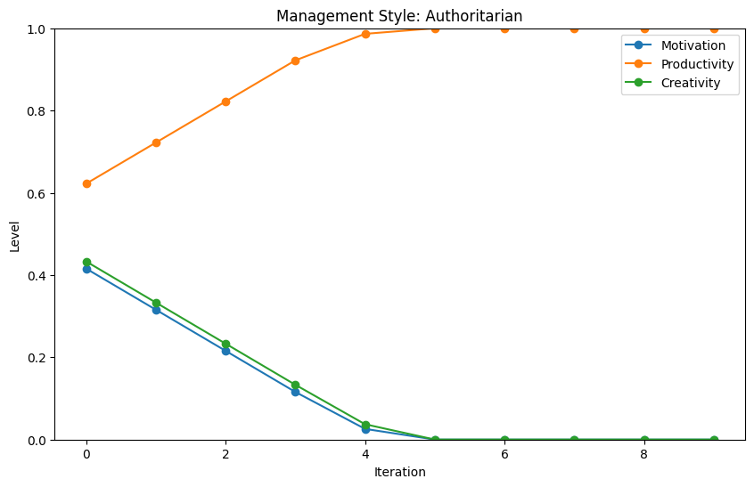

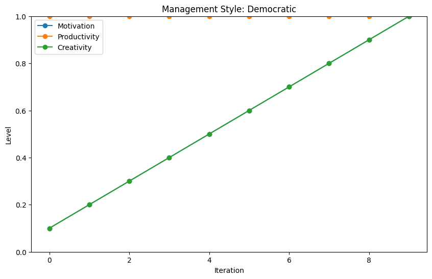

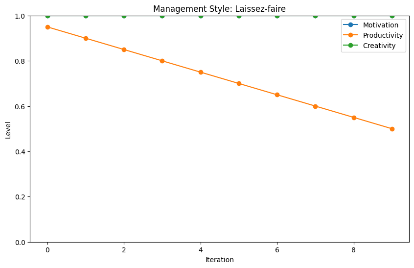

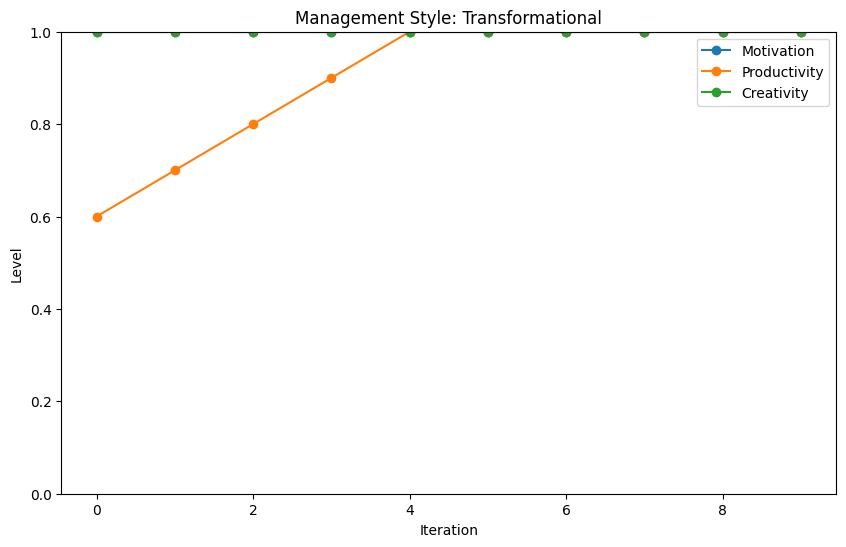

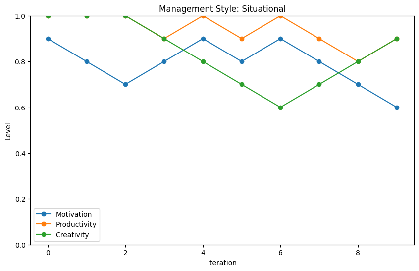

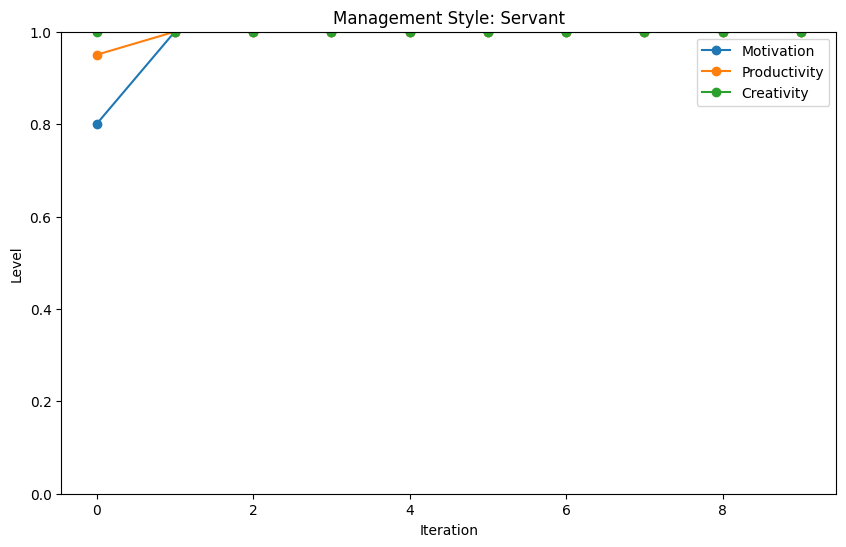

```python
# Management Styles Simulation Notebook

import numpy as np
import matplotlib.pyplot as plt
import random

# Setting up initial parameters
team_size = 10  # Number of team members
iterations = 10  # Number of project iterations
management_styles = ["Authoritarian", "Democratic", "Laissez-faire", "Transformational", "Situational", "Servant"]

# Initial team state (randomized initial motivation, productivity, creativity levels)
team_state = {
    "motivation": np.random.uniform(0.4, 0.6, team_size),
    "productivity": np.random.uniform(0.4, 0.6, team_size),
    "creativity": np.random.uniform(0.4, 0.6, team_size),
}

# Define how each management style affects the team state
def apply_management_style(style, team_state):
    if style == "Authoritarian":
        team_state["motivation"] -= 0.1
        team_state["productivity"] += 0.1
        team_state["creativity"] -= 0.1
    elif style == "Democratic":
        team_state["motivation"] += 0.1
        team_state["productivity"] += 0.05
        team_state["creativity"] += 0.1
    elif style == "Laissez-faire":
        team_state["motivation"] += 0.05
        team_state["productivity"] -= 0.05
        team_state["creativity"] += 0.15
    elif style == "Transformational":
        team_state["motivation"] += 0.15
        team_state["productivity"] += 0.1
        team_state["creativity"] += 0.1
    elif style == "Situational":
        team_state["motivation"] += np.random.choice([-0.1, 0.1])
        team_state["productivity"] += np.random.choice([-0.1, 0.1])
        team_state["creativity"] += np.random.choice([-0.1, 0.1])
    elif style == "Servant":
        team_state["motivation"] += 0.2
        team_state["productivity"] += 0.05
        team_state["creativity"] += 0.1

    # Ensure values stay between 0 and 1
    for key in team_state:
        team_state[key] = np.clip(team_state[key], 0, 1)
    return team_state

# Simulation function
def run_simulation(style):
    motivation_history, productivity_history, creativity_history = [], [], []

    for _ in range(iterations):
        apply_management_style(style, team_state)
        motivation_history.append(np.mean(team_state["motivation"]))
        productivity_history.append(np.mean(team_state["productivity"]))
        creativity_history.append(np.mean(team_state["creativity"]))

    return motivation_history, productivity_history, creativity_history

# Plotting function
def plot_results(style, motivation, productivity, creativity):
    plt.figure(figsize=(10, 6))
    plt.plot(motivation, label="Motivation", marker="o")
    plt.plot(productivity, label="Productivity", marker="o")
    plt.plot(creativity, label="Creativity", marker="o")
    plt.title(f"Management Style: {style}")
    plt.xlabel("Iteration")
    plt.ylabel("Level")
    plt.legend()
    plt.ylim(0, 1)
    plt.show()

# Run simulation and plot results for each management style
for style in management_styles:
    motivation, productivity, creativity = run_simulation(style)
    plot_results(style, motivation, productivity, creativity)
```

### Erklärung

1. **Initialzustand**: Das Team startet mit zufälligen Motivation-, Produktivitäts- und Kreativitätswerten.
2. **Management-Stile**: Jeder Managementstil beeinflusst diese Werte anders:
   - **Authoritarian**: Senkt Motivation und Kreativität, erhöht Produktivität leicht.
   - **Democratic**: Erhöht Motivation, Kreativität und Produktivität leicht.
   - **Laissez-faire**: Erhöht Kreativität und Motivation leicht, senkt aber Produktivität.
   - **Transformational**: Erhöht Motivation, Kreativität und Produktivität.
   - **Situational**: Zufällige Schwankungen je nach Situation.
   - **Servant**: Erhöht Motivation und Kreativität stark, Produktivität leicht.
3. **Simulation**: Die Funktion `run_simulation` führt das Team durch mehrere Iterationen eines Managementstils und zeichnet die Entwicklungen in den drei Hauptbereichen auf.
4. **Visualisierung**: Die `plot_results`-Funktion stellt die Veränderungen der Teamwerte grafisch dar, sodass die Auswirkungen jeder Stilrichtung leicht sichtbar werden.

Dieses Notebook ermöglicht es, die Auswirkungen der Managementstile zu beobachten und spielerisch zu verstehen.